# Self-Driving Car Engineer Nanodegree

## Project: Build a Traffic Sign Recognition Classifier

## Step 0: Load The Data

We have the German Traffic Sign Data set that we will use to train, refine and test the Convolutional Neural Net.

```python
# Load pickled data
import pickle

#loading our variables from the dataset

training_file = 'train.p'
validation_file = 'valid.p'
testing_file = 'test.p'

with open(training_file, mode='rb') as f:
    train = pickle.load(f)
with open(validation_file, mode='rb') as f:
    valid = pickle.load(f)
with open(testing_file, mode='rb') as f:
    test = pickle.load(f)

X_train, y_train = train['features'], train['labels']
X_validationO, y_validation = valid['features'], valid['labels']
X_test, y_test = test['features'], test['labels']
```

## Step 1: Dataset Summary & Exploration

The pickled data is a dictionary with 4 key/value pairs:

- `'features'` is a 4D array containing raw pixel data of the traffic sign images, (num examples, width, height, channels).
- `'labels'` is a 1D array containing the label/class id of the traffic sign. The file `signnames.csv` contains id -> name mappings for each id.
- `'sizes'` is a list containing tuples, (width, height) representing the original width and height the image.
- `'coords'` is a list containing tuples, (x1, y1, x2, y2) representing coordinates of a bounding box around the sign in the image. **THESE COORDINATES ASSUME THE ORIGINAL IMAGE. THE PICKLED DATA CONTAINS RESIZED VERSIONS (32 by 32) OF THESE IMAGES**

### A Basic Summary of the Data Set

```python
import numpy as np

#number of data in each category
n_train = len(X_train)
n_validationO = len(X_validationO)
n_test = len(X_test)

#shape of our image
image_shape = X_train.shape[1:]

#How many unique classes/labels there are in the dataset.
n_classes = len(np.unique(y_train))

print("Number of training examples =", n_train)
print("Number of validation examples =", n_validationO)
print("Number of testing examples =", n_test)
print("Image data shape =", image_shape)
print("Number of classes =", n_classes)
```

```
Number of training examples = 34799
Number of validation examples = 4410
Number of testing examples = 12630
Image data shape = (32, 32, 3)
Number of classes = 43
```

### An exploratory visualization of the dataset

```python
### We just randomly pick 10 images from the dataset to visualize and get an idea of what we're dealing with
import matplotlib.pyplot as plt
import random
import numpy as np
# Visualizations will be shown in the notebook.
%matplotlib inline

for i in range(0,10):
    index = random.randint(0, len(X_train))
    image = X_train[index]

    plt.figure(figsize=(1,1))
    plt.imshow(image)
```

[output not shown]

## Step 2: Design and Test a Model Architecture

Now, we design and implement a deep learning model that learns to recognize traffic signs. We will train and test the model on the [German Traffic Sign Dataset]

The LeNet-5 implementation is a great starting point. However, all the fun is in poking and prodding the model to see how it behaves. So we can learn how the model learns!

We can play with various aspects for this problem:

- Neural network architecture (is the network over or underfitting?)
- Play around preprocessing techniques (normalization, rgb to grayscale, etc)
- Number of examples per label (some have more than others).
- Generate fake data.

Here is an example of a [published baseline model on this problem](http://yann.lecun.com/exdb/publis/pdf/sermanet-ijcnn-11.pdf).

### Pre-process the Data Set (normalization, grayscale, etc.)

The most fundamental thing to do is mean normalization. This allows the optimization program to converge faster instead of being skewed in some direction. The image data should be normalized so that the data has mean zero and equal variance.

I tried converting to grayscale, or even converting to the YUV color space outlined in the above paper. However, I read that using an initial 3 1x1 filter allows the model to learn it's own best form of color space transform. Seemed pretty cool, so let's go with that! (*Spoilers*, it gives a huge jump in accuracy)

```python
#Shuffling  the data is always a great way to ensure some randomness
from sklearn.utils import shuffle
X_train, y_train = shuffle(X_train, y_train)

#Mean normalization
X_train = ((X_train/128) - 1)
X_validation = ((X_validationO/128) - 1)
X_test  = ((X_test/128) - 1)

#We choose a random image to see what it looks like
index = random.randint(0, len(X_train))
image = X_train[index].squeeze()

plt.figure(figsize=(1,1))
plt.imshow(image)
```

[output not shown]

### Class Visualization

Another great thing to do is gain an intuition about the spread of the data set. This lets us know if something is skewed in a direction or not. It seems from the visualization, some classes are weighted much more heavily than the others. What this leads to is an internal bias to our classifier. If say it can't decide between a "No vehicle" sign and a "No entry" sign because they both look very similar, it will choose the sign that has more data points. Hence, a bias.

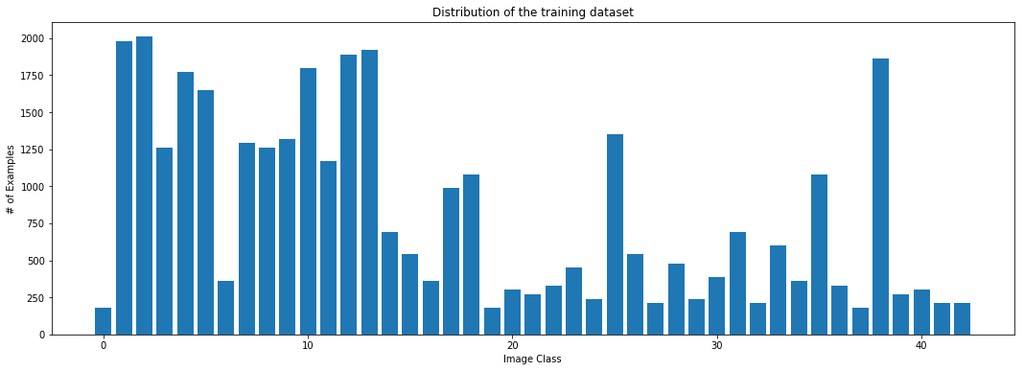

```python
# Another great thing to do is gain an intuition about the spread of the data set

def plot_images_per_class(labels_):
    values, counts = np.unique(labels_,return_counts=True)
    plt.figure(figsize = (18,6))
    plt.bar(values, counts)
    plt.ylabel('# of Examples')
    plt.xlabel('Image Class')
    plt.title("Distribution of the training dataset")

plot_images_per_class(y_train)
```

### Data Augmentation

The bias in the data set may probably be due to the nature of the probability of encountering these datasets. We're more likely to see a "Stop" sign rather than a "Falling rocks" sign. So to get rid of this bias we can augment the data by generating new images. We do this by "jittering" our images. So basically taking the image and translating it, rotating it, or shearing it ever so slightly to give the Neural net a different perspective.

```python
import matplotlib.gridspec as gridspec
import cv2
import matplotlib.image as mpimg
```

```python
def augment_brightness(image):

    """ Randomly change the britness of the image
    """
    #transforming the image from RGB to HSC
    image1 = cv2.cvtColor(image,cv2.COLOR_RGB2HSV)
    random_bright = .25+np.random.uniform()
    #adding random brightness to the image
    image1[:,:,2] = image1[:,:,2]*random_bright
    #transforming the image back to RGB
    image1 = cv2.cvtCOLOR(image1,cv2.COLOR_HSV2RGB)
    return image1
```

```python
def transform_image(img,ang_range, shear_range, trans_range):

    """Changes the image's angle, shear, brightness, and translation"""

    #Rotate the image

    angle_rot = np.random.uniform(ang_range) - ang_range/2
    row,col,channel = img.shape
    rotation = cv2.getRotationMatrix2D((col/2,row/2),angle_rot,1)

    #Translate the image

    trans_x = trans_range*np.random.uniform()-trans_range/2
    trans_y = trans_range*np.random.uniform()-trans_range/2
    translation = np.float32([[1,0,trans_x],[0,1,trans_y]])

    # Shear
    pts1 = np.float32([[5,5],[20,5],[5,20]])

    pt1 = 5+shear_range*np.random.uniform()-shear_range/2
    pt2 = 20+shear_range*np.random.uniform()-shear_range/2

    pts2 = np.float32([[pt1,5],[pt2,pt1],[5,pt2]])

    shear_M = cv2.getAffineTransform(pts1,pts2)

    Shear the image
    p1 = np.float32([[5,5],[20,5],[5,20]])
    p1 = 5+shear_range*np.random.uniform()-shear_range/2
    p2 = 20+shear_range*np.random.uniform()-shear_range/2
    p2 = np.float32([[p1,5],[p2,p1],[5,p2]])


    img = cv2.warpAffine(img,rotation, (col,row))
    img = cv2.warpAffine(img,translation,(col,row))
    img = cv2.warpAffine(img,shear_M,(col,row))

    #Brighten the image randomly
    #img = augment_brightness(img)

    return img
```

```python
values, count = np.unique(y_train,return_counts=True)
max_images = 2000

for class_ in values:
    if count[class_] < 2000:
        images_needed = max_images - count[class_]
        print('Working on class #', class_)
        id = next(index for index, val in enumerate(y_train) if val==class_)
        id = X_train[id]
        print ("@")
        class_ = class_.reshape([1])
        print ("@")
        for i in range(images_needed):
            print ("@")
            image = transform_image(id, 10,10,5)
            image = image.reshape([1,32,32,3])
            X_train = np.concatenate([X_train,image])
            y_train = np.concatenate([y_train,class_])
```

```python
plot_images_per_class(y_train)
```

[output not shown]

```python
index = random.randint(0, len(X_train))
image = X_train[index].squeeze()

plt.figure(figsize=(1,1))
plt.imshow(image)
```

[output not shown]

```python
import os

pickle_file = 'transformed_data_2.pickle'

if not os.path.isfile(pickle_file):
    print('Saving data to pickle file...')
    try:
        with open('transformed_data_2.pickle', 'wb') as pfile:
            pickle.dump(
                {
                    'X_train': X_train,
                    'y_train': y_train,
                },
                pfile, pickle.HIGHEST_PROTOCOL)
    except Exception as e:
        print('Unable to save data to', pickle_file, ':', e)
        raise

print('Data cached in pickle file.')
```

### Neural Network Architecture

My Neural Network Architecture heavily employs dropouts. Being a UofT Alumni myself, I have to follow in the footsteps of AlexNet and Geoffrey Hinton, haha! However, on a more serious note the redundancy provided by the method makes a huge difference in the final accuracy. It ensures that the model doesn't overfit and translates well to the test set.

I used 3 1x1 filters to learn the images best color space transform. Following which I used a series of 3x3 convolutions with filter sizes doubling at 16, 32, 64, and 128. Max pooling was strategically employed to bring the image down to a 5x5 spatial area from 32x32.

```python
import tensorflow as tf
from tensorflow.contrib.layers import flatten

keep_prob = tf.placeholder(tf.float32)

def LeNet(x):
    # Arguments used for tf.truncated_normal, randomly defines variables for the weights and biases for each layer
    mu = 0
    sigma = 0.1

    #First convolutional layer to using 3 1x1 filters for the system to learn color mapping
    weight = tf.Variable(tf.truncated_normal(shape=(1,1,3,3),mean=mu, stddev=sigma))
    bias = tf.Variable(tf.zeros(3))
    conv_layer= tf.nn.conv2d(x, weight,strides=[1,1,1,1], padding = 'VALID')
    conv_layer = tf.nn.bias_add(conv_layer, bias)
    conv_layer = tf.nn. relu(conv_layer)

    weight1 = tf.Variable(tf.truncated_normal(shape=(3,3,3,16),mean=mu, stddev=sigma))
    bias1 = tf.Variable(tf.zeros(16))
    #Layer 1: Convolutional. Input = 32x32x3. Output = 30x30x32.
    conv_layer= tf.nn.conv2d(conv_layer, weight1,strides=[1,1,1,1], padding = 'VALID')
    conv_layer = tf.nn.bias_add(conv_layer, bias1)
    #conv_layer = tf.nn.max_pool(conv_layer, ksize = [1,2,2,1], strides=[1,2,2,1], padding = "VALID")
    conv_layer = tf.nn.dropout(conv_layer, keep_prob)

    weight2 = tf.Variable(tf.truncated_normal(shape=(3,3,16,32),mean=mu, stddev=sigma))
    bias2 = tf.Variable(tf.zeros(32))
    #Layer 2: Convolutional. Input = 30x30x32. Output = 28x28x64-->14x14x64 with max pooling
    conv_layer= tf.nn.conv2d(conv_layer, weight2,strides=[1,1,1,1], padding = 'VALID')
    conv_layer = tf.nn.bias_add(conv_layer, bias2)
    conv_layer = tf.nn.max_pool(conv_layer, ksize = [1,2,2,1], strides=[1,2,2,1], padding = "VALID")
    conv_layer = tf.nn.dropout(conv_layer, keep_prob)

    weight3 = tf.Variable(tf.truncated_normal(shape=(3,3,32,64),mean=mu, stddev=sigma))
    bias3 = tf.Variable(tf.zeros(64))
    #Layer 3: Convolutional. Input = 14x14x32. Output = 12x12x64.
    conv_layer= tf.nn.conv2d(conv_layer, weight3,strides=[1,1,1,1], padding = 'VALID')
    conv_layer = tf.nn.bias_add(conv_layer, bias3)
    #conv_layer = tf.nn.max_pool(conv_layer, ksize = [1,2,2,1], strides=[1,2,2,1], padding = "VALID")
    #conv_layer = tf.nn.dropout(conv_layer, keep_prob)

    weight4 = tf.Variable(tf.truncated_normal(shape=(3,3,64,128),mean=mu, stddev=sigma))
    bias4 = tf.Variable(tf.zeros(128))
    #Layer 4: Convolutional. Input = 12x12x64. Output = 5x5x128.
    conv_layer= tf.nn.conv2d(conv_layer, weight4,strides=[1,1,1,1], padding = 'VALID')
    conv_layer = tf.nn.bias_add(conv_layer, bias4)
    conv_layer = tf.nn.max_pool(conv_layer, ksize = [1,2,2,1], strides=[1,2,2,1], padding = "VALID")
    conv_layer = tf.nn.dropout(conv_layer, keep_prob)


    #Flatten the convolutional layers so we can connect to traditional fully connected layers
    fc0 = flatten(conv_layer)
    # Layer 5: Fully Connected. Input = 400. Output = 120.
    weights_fc1 = tf.Variable(tf.truncated_normal(shape=(5*5*128,128),mean=mu,stddev=sigma))
    bias_fc1 = tf.Variable(tf.zeros(128))
    fc1 = tf.add(tf.matmul(fc0,weights_fc1),bias_fc1)
    fc1 = tf.nn.relu(fc1)
    fc1 = tf.nn.dropout(fc1,keep_prob)

    #Layer 6: Fully Connected. Input = 120. Output = 84.
    weights_fc2 = tf.Variable(tf.truncated_normal(shape=(128,84),mean=mu,stddev=sigma))
    bias_fc2 = tf.Variable(tf.zeros(84))
    fc2 = tf.add(tf.matmul(fc1,weights_fc2),bias_fc2)
    fc2=tf.nn.relu(fc2)
    fc2 = tf.nn.dropout(fc2,keep_prob)

    #Final Layer: Fully Connected. Input = 84. Output = 43 for our 43 classes
    weights_final = tf.Variable(tf.truncated_normal(shape=(84,43),mean=mu,stddev=sigma))
    bias_final = tf.Variable(tf.zeros(43))
    logits = tf.add(tf.matmul(fc2,weights_final),bias_final)

    return logits
```

### Train, Validate and Test the Model

A validation set can be used to assess how well the model is performing. A low accuracy on the training and validation sets imply underfitting. A high accuracy on the training set but low accuracy on the validation set implies overfitting.

```python
x = tf.placeholder(tf.float32, (None, 32,32,3))
y = tf.placeholder(tf.int32, (None))
one_hot_y = tf.one_hot(y,43)  #we need to one hot encode our data set
```

### Model Training Pipeline

```python
### We need to create a pipleline to train the model.

#Define the training parameters such as learning rate, number of epochs, and batch size

EPOCHS = 100
BATCH_SIZE = 128
rate = 0.00075

logits = LeNet(x)

cross_entropy = tf.nn.softmax_cross_entropy_with_logits(logits=logits, labels = one_hot_y)
loss = tf.reduce_mean(cross_entropy)
optimizer = tf.train.AdamOptimizer(learning_rate = rate)
training_operation = optimizer.minimize(loss)
```

### Model Evaluation Pipeline

```python
correct_prediction = tf.equal(tf.argmax(logits, 1), tf.argmax(one_hot_y, 1))
accuracy_operation = tf.reduce_mean(tf.cast(correct_prediction, tf.float32))
saver = tf.train.Saver()

def evaluate(X_data, y_data):
    num_examples = len(X_data)
    total_accuracy = 0
    sess = tf.get_default_session()
    for offset in range(0, num_examples, BATCH_SIZE):
        batch_x, batch_y = X_data[offset:offset+BATCH_SIZE], y_data[offset:offset+BATCH_SIZE]
        accuracy = sess.run(accuracy_operation, feed_dict={x: batch_x, y: batch_y, keep_prob: 1})
        total_accuracy += (accuracy * len(batch_x))
    return total_accuracy / num_examples
```

### Training the Model

```
Training..

EPOCH 1 ...
Validation Accuracy = 0.386

EPOCH 2 ...
Validation Accuracy = 0.478

EPOCH 3 ...
Validation Accuracy = 0.532

EPOCH 4 ...
Validation Accuracy = 0.605

EPOCH 5 ...
Validation Accuracy = 0.714

EPOCH 6 ...
Validation Accuracy = 0.785

EPOCH 7 ...
Validation Accuracy = 0.828

EPOCH 8 ...
Validation Accuracy = 0.856

EPOCH 9 ...
Validation Accuracy = 0.864

EPOCH 10 ...
Validation Accuracy = 0.885

EPOCH 11 ...
Validation Accuracy = 0.914

EPOCH 12 ...
Validation Accuracy = 0.920

EPOCH 13 ...
Validation Accuracy = 0.926
```

[output cut: 248 more lines]

```
Validation Accuracy = 0.978

EPOCH 97 ...
Validation Accuracy = 0.975

EPOCH 98 ...
Validation Accuracy = 0.978

EPOCH 99 ...
Validation Accuracy = 0.976

EPOCH 100 ...
Validation Accuracy = 0.979

Model saved
```

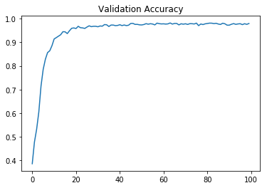

```python
with tf.Session() as sess:
    sess.run(tf.global_variables_initializer())
    num_examples = len(X_train)

    print("Training..")
    print()

    validation_accuracy_figure = []

    for i in range(EPOCHS):
        X_train, y_train = shuffle(X_train, y_train)
        for offset in range(0, num_examples, BATCH_SIZE):
            end = offset + BATCH_SIZE
            batch_x, batch_y = X_train[offset:end], y_train[offset:end]
            sess.run(training_operation, feed_dict={x: batch_x, y: batch_y, keep_prob: 0.5})

        validation_accuracy = evaluate(X_validation, y_validation)
        validation_accuracy_figure.append(validation_accuracy)
        print("EPOCH {} ...".format(i+1))
        print("Validation Accuracy = {:.3f}".format(validation_accuracy))
        print()

    saver.save(sess, './TrafficSignClassifierlongthin')
    print ("Model saved")

    plt.plot(validation_accuracy_figure)
    plt.title("Validation Accuracy")
    plt.show()
```

### Train accuracy

```python
with tf.Session() as sess:
    saver.restore(sess, tf.train.latest_checkpoint('.'))

    test_accuracy = evaluate(X_train, y_train)
    print("Test Accuracy = {:.3f}".format(test_accuracy))
```

```
Test Accuracy = 0.998
```

### Testing the Model

```python
with tf.Session() as sess:
    saver.restore(sess, tf.train.latest_checkpoint('.'))

    test_accuracy = evaluate(X_test, y_test)
    print("Test Accuracy = {:.3f}".format(test_accuracy))
```

```
Test Accuracy = 0.970
```

## Step 3: Test a Model on New Images

Now to gain more insight into how the model is working, we download at least five pictures of German traffic signs from the web and use the model to predict the traffic sign type.

### Load and Output the Images

```
(6, 32, 32, 3)
```

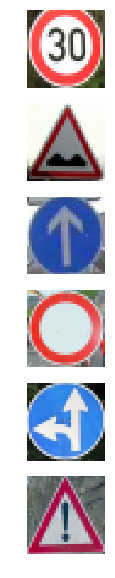

```python
import matplotlib.pyplot as plt
%matplotlib inline
import tensorflow as tf
import numpy as np
import cv2
import glob
import matplotlib.image as mpimg

fig, axs = plt.subplots(6,1, figsize=(4,10))
fig.subplots_adjust(hspace = .2, wspace=.001)
axs = axs.ravel()

my_images = []

for i, img in enumerate(glob.glob('./test_images/*.png')):
    image = cv2.imread(img)
    axs[i].axis('off')
    axs[i].imshow(cv2.cvtColor(image, cv2.COLOR_BGR2RGB))
    my_images.append(image)

my_images = np.asarray(my_images)
my_images_normalized = ((my_images/128) - 1) #should normalize these images too before we feed them to the model!

print(my_images_normalized.shape)
```

### Analyze the accuracy of classifier on these new images

```python
### Calculate the accuracy for these 5 new images.



my_labels = [1, 22, 35, 15, 37, 18]


with tf.Session() as sess:
    sess.run(tf.global_variables_initializer())
    saver.restore(sess, tf.train.latest_checkpoint('.'))
    my_accuracy = evaluate(my_images_normalized, my_labels)
    print("Test Set Accuracy = {:.3f}".format(my_accuracy))
```

```
Test Set Accuracy = 0.500
```

### Sign type classification prediction of each image

### Output Top 5 Softmax Probabilities For Each Image Found on the Web

To find which image is being classified wrong and why we can go over the softmax probabilities of the predictions. This will tell us what class the image is being predicted as and how sure it is.

[figure not shown]

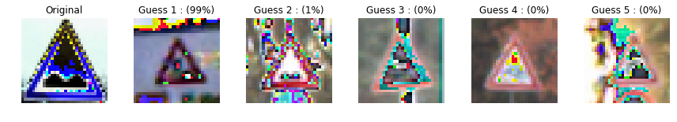

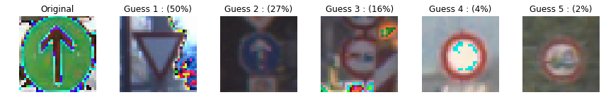

[figure not shown]

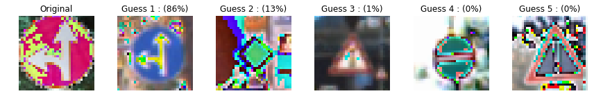

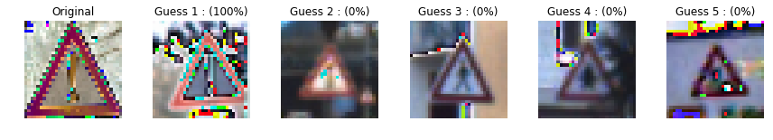

```python
### Printing out the top five softmax probabilities for the predictions on the German traffic sign images found on the web.

#Should have probably created a function from the start but oh well!
def plot_figures(figures, nrows = 1, ncols=1, labels=None):

    fig, axs = plt.subplots(ncols=ncols, nrows=nrows, figsize=(12, 14))
    axs = axs.ravel()

    for index, title in zip(range(len(figures)), figures):
        axs[index].imshow(figures[title])
        if(labels != None):
           axs[index].set_title(labels[index])
        else:
            axs[index].set_title(title)
        axs[index].set_axis_off()
    plt.tight_layout()


softmax_logits = tf.nn.softmax(logits)
top_k = tf.nn.top_k(softmax_logits, k=5)

with tf.Session() as sess:
    sess.run(tf.global_variables_initializer())
    saver.restore(sess, tf.train.latest_checkpoint('.'))
    my_softmax_logits = sess.run(softmax_logits, feed_dict={x: my_images_normalized, keep_prob: 1.0})
    my_top_k = sess.run(top_k, feed_dict={x: my_images_normalized, keep_prob: 1.0})

    for i in range(6):
        figures = {}
        labels = {}
        figures[0] = my_images_normalized[i]
        labels[0] = "Original"

        for j in range(5):
            labels[j+1] = 'Guess {} : ({:.0f}%)'.format(j+1, 100*my_top_k[0][i][j])
            figures[j+1] = X_validation[np.argwhere(y_validation == my_top_k[1][i][j])[0]].squeeze()

        plot_figures(figures, 1, 6, labels)
```

Yikes! That's scary. This is probably because we're seeing all the normalized images. How about we check out the regular ones below.

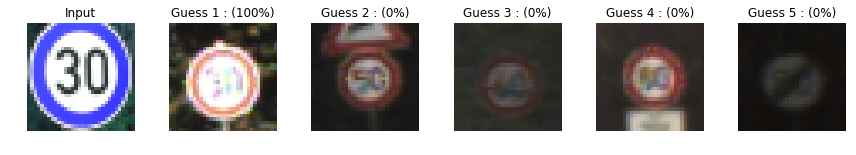

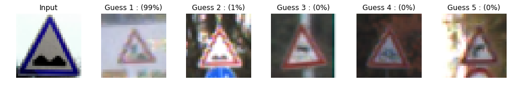

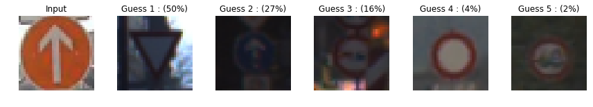

[figure not shown]

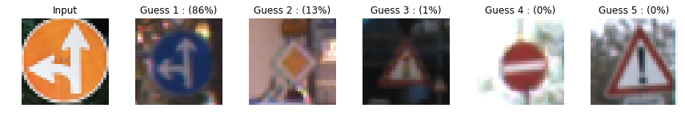

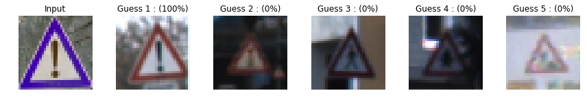

```python
### Printing out the top five softmax probabilities for the predictions on the German traffic sign images found on the web.

softmax_logits = tf.nn.softmax(logits)
top_k = tf.nn.top_k(softmax_logits, k=5)

with tf.Session() as sess:
    sess.run(tf.global_variables_initializer())
    saver.restore(sess, tf.train.latest_checkpoint('.'))
    my_softmax_logits = sess.run(softmax_logits, feed_dict={x: my_images_normalized, keep_prob: 1.0})
    my_top_k = sess.run(top_k, feed_dict={x: my_images_normalized, keep_prob: 1.0})

    for i in range(6):
        figures = {}
        labels = {}
        figures[0] = my_images[i]
        labels[0] = "Input"

        for j in range(5):
            labels[j+1] = 'Guess {} : ({:.0f}%)'.format(j+1, 100*my_top_k[0][i][j])
            figures[j+1] = X_validationO[np.argwhere(y_validation == my_top_k[1][i][j])[0]].squeeze()

        plot_figures(figures, 1, 6, labels)
```

## Step 4 (Optional): Visualize the Neural Network's State with Test Images

While neural networks can be a great learning device they are often referred to as a black box. We can understand what the weights of a neural network look like better by plotting their feature maps. After successfully training your neural network you can see what it's feature maps look like by plotting the output of the network's weight layers in response to a test stimuli image. From these plotted feature maps, it's possible to see what characteristics of an image the network finds interesting. For a sign, maybe the inner network feature maps react with high activation to the sign's boundary outline or to the contrast in the sign's painted symbol.

Provided below is the function code that allows you to get the visualization output of any tensorflow weight layer you want. The inputs to the function should be a stimuli image, one used during training or a new one you provided, and then the tensorflow variable name that represents the layer's state during the training process, for instance if you wanted to see what the LeNet lab's feature maps looked like for it's second convolutional layer you could enter conv2 as the tf_activation variable.

For an example of what feature map outputs look like, check out NVIDIA's results in their paper [End-to-End Deep Learning for Self-Driving Cars](https://devblogs.nvidia.com/parallelforall/deep-learning-self-driving-cars/) in the section Visualization of internal CNN State. NVIDIA was able to show that their network's inner weights had high activations to road boundary lines by comparing feature maps from an image with a clear path to one without. Try experimenting with a similar test to show that your trained network's weights are looking for interesting features, whether it's looking at differences in feature maps from images with or without a sign, or even what feature maps look like in a trained network vs a completely untrained one on the same sign image.

[figure not shown]

Your output should look something like this (above)

```python
### Visualize your network's feature maps here.
### Feel free to use as many code cells as needed.

# image_input: the test image being fed into the network to produce the feature maps
# tf_activation: should be a tf variable name used during your training procedure that represents the calculated state of a specific weight layer
# activation_min/max: can be used to view the activation contrast in more detail, by default matplot sets min and max to the actual min and max values of the output
# plt_num: used to plot out multiple different weight feature map sets on the same block, just extend the plt number for each new feature map entry

def outputFeatureMap(image_input, tf_activation, activation_min=-1, activation_max=-1 ,plt_num=1):
    # Here make sure to preprocess your image_input in a way your network expects
    # with size, normalization, ect if needed
    # image_input =
    # Note: x should be the same name as your network's tensorflow data placeholder variable
    # If you get an error tf_activation is not defined it may be having trouble accessing the variable from inside a function
    activation = tf_activation.eval(session=sess,feed_dict={x : image_input})
    featuremaps = activation.shape[3]
    plt.figure(plt_num, figsize=(15,15))
    for featuremap in range(featuremaps):
        plt.subplot(6,8, featuremap+1) # sets the number of feature maps to show on each row and column
        plt.title('FeatureMap ' + str(featuremap)) # displays the feature map number
        if activation_min != -1 & activation_max != -1:
            plt.imshow(activation[0,:,:, featuremap], interpolation="nearest", vmin =activation_min, vmax=activation_max, cmap="gray")
        elif activation_max != -1:
            plt.imshow(activation[0,:,:, featuremap], interpolation="nearest", vmax=activation_max, cmap="gray")
        elif activation_min !=-1:
            plt.imshow(activation[0,:,:, featuremap], interpolation="nearest", vmin=activation_min, cmap="gray")
        else:
            plt.imshow(activation[0,:,:, featuremap], interpolation="nearest", cmap="gray")
```